# Comprehensive data analysis with house price project

**Guidance**

1. **Understand the problem**: We'll look at each variable and do a philosophical analysis about their meaning and importance for this problem
2. **Univariable study**: We'll just focus on the dependent variable and independent little bit more about it.
3. **Multivariate study**: We'll try to understand how the dependent variable and variables related
4. **Basic Cleaning**: Wel'll clean the dataset and handle the missing data, outliers and categorical variables.
5. **Test assumptions**: We'll check if our data meets the assumptions required by most multivariate techniques

```python
#invite people for the Kaggle party

import pandas as pd
import matplotlib.pyplot as plt
import seaborn as sns
import numpy as np
from scipy.stats import norm
from sklearn.preprocessing import StandardScaler
from scipy import stats
import warnings
warnings.filterwarnings('ignore')
%matplotlib inline
```

```python
#bring in the six packs

df_train = pd.read_csv('train.csv')
```

```python
#Check t he decoration
df_train.columns
```

```
Index(['Id', 'MSSubClass', 'MSZoning', 'LotFrontage', 'LotArea', 'Street',
       'Alley', 'LotShape', 'LandContour', 'Utilities', 'LotConfig',
       'LandSlope', 'Neighborhood', 'Condition1', 'Condition2', 'BldgType',
       'HouseStyle', 'OverallQual', 'OverallCond', 'YearBuilt', 'YearRemodAdd',
       'RoofStyle', 'RoofMatl', 'Exterior1st', 'Exterior2nd', 'MasVnrType',
       'MasVnrArea', 'ExterQual', 'ExterCond', 'Foundation', 'BsmtQual',
       'BsmtCond', 'BsmtExposure', 'BsmtFinType1', 'BsmtFinSF1',
       'BsmtFinType2', 'BsmtFinSF2', 'BsmtUnfSF', 'TotalBsmtSF', 'Heating',
       'HeatingQC', 'CentralAir', 'Electrical', '1stFlrSF', '2ndFlrSF',
       'LowQualFinSF', 'GrLivArea', 'BsmtFullBath', 'BsmtHalfBath', 'FullBath',
       'HalfBath', 'BedroomAbvGr', 'KitchenAbvGr', 'KitchenQual',
       'TotRmsAbvGrd', 'Functional', 'Fireplaces', 'FireplaceQu', 'GarageType',
       'GarageYrBlt', 'GarageFinish', 'GarageCars', 'GarageArea', 'GarageQual',
       'GarageCond', 'PavedDrive', 'WoodDeckSF', 'OpenPorchSF',
       'EnclosedPorch', '3SsnPorch', 'ScreenPorch', 'PoolArea', 'PoolQC',
       'Fence', 'MiscFeature', 'MiscVal', 'MoSold', 'YrSold', 'SaleType',
       'SaleCondition', 'SalePrice'],
      dtype='object')
```

# . So...What can we expect?

In order to understand our data, we can look at each variable and try to understand their meaning and relevance to this problem. I know this is time-consuming, but it will give us the falvour of our dataset.

In order to have some discipline in our analysis, we can create Excel spreadsheet with the following columns:

- **Variable**: Variable name
- **Type**: Identification of the variables type. There are two possible valuesfor this field: 'numerical' and 'categorical' we mean variables for which the values are categories
- **Segment**: Identification of the variables segment. We can define three possible segments: building, space or location. When we say 'building;, we mean a variable that relates to the physical characteristics of the building. When we say 'space' we mean a variable that reports space propertities of the house. Finally, when we say a location, we mean a variable that gives information about the place where the house is located
- **Expectation**: Our expectation about the variable influence in 'SalePrice'. We can use a categorical scale with 'High', 'Medium' and 'Low' as possible values
- **Conclusion**: Our conclusions about the importance of the variable, after we give a quick look at the data. We can keep with the same categorical scale as in 'Expectation;
- **Comments**: Any general comments that occured to us

While 'Type' and 'Segment' is just for possible future reference, the column 'Expectation' is important because it will help us develop a ;sixth sense'. To fill this column, we should read the description of all the variables, one by one, ask ourselves:

- Do we think about this variable when we are buying a house?
- If so, how important would this variable be?
- If this information already described iin any other variable?

After this daunting exercise, we can filter the spreadsheet and look carefully to the variables with 'High' Expectation. Then we can rush into some scatter plots between those variables and 'SalePrice', filling in the 'Conclusion; column which is just the correaction of our expectation.

I went through this process and concluded that the following variables can play an important role in this problem:

- OverallQuall(which is a variable that I don't like because I don't know how it was computed; a funny exercise would be to predict 'OverallQual' using all the other variables available)
- YearBuilt
- TotalBsmtSF
- GrLvArea

I ended up with two 'building' variables ('OverallQual' and 'YearBuilt') and two 'space' variables ('TotalBsmtSF' and 'GrLivArea'). This might be a little bit unexpected as it goes against the real estate mantra that all that matters is location. It is possible that this quick data examination process was a bit harsh for categorical variables. For example, I expected the 'Neighborhood; variable to be more relevant, but after the data examination I ended up excluding it. Maybe this is related to the use of scatter plots instead of boxplots, which are more suitable for categorical variables visualization. The way we visualize data often influences our conclusions.

However, the main point of this exercise was to think a little about our data and expectations, so I think we achieved our goal. Now it's time for a little less conversation, a little more action.

# First things first: analyzing 'SalePrice'

'SalePrice' is the reason of our quest. It's like when we're going to a party. We always have a reason to be there. Usually, women are that reason

```python
df_train['SalePrice'].describe()
```

```
count      1460.000000
mean     180921.195890
std       79442.502883
min       34900.000000
25%      129975.000000
50%      163000.000000
75%      214000.000000
max      755000.000000
Name: SalePrice, dtype: float64
```

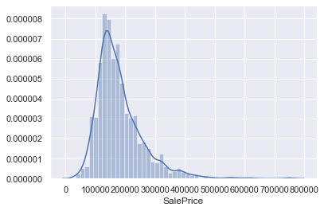

```python
#histogram
sns.distplot(df_train['SalePrice'])
```

- Deviate from the normal distribution
- Have appreciable positive skewness
- Show peakedness

```python
#skewness and kurtosis

print('Skewness : %f' % df_train['SalePrice'].skew())
print('Kurtosis : %f' % df_train['SalePrice'].kurt())
```

```
Skewness : 1.882876
Kurtosis : 6.536282
```

## Relationship with numerical variables

[output not shown]

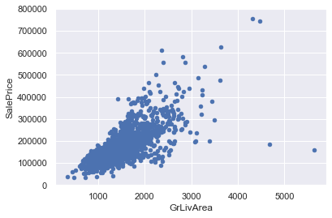

```python
#scatter plot grlivarea/saleprice

var = 'GrLivArea'
data = pd.concat([df_train['SalePrice'], df_train[var]], axis = 1)
data.plot.scatter(x=var, y ='SalePrice', ylim=(0, 800000))
```

It seems that 'SalePrice' and 'GrLiArea' are linear relationship

[output not shown]

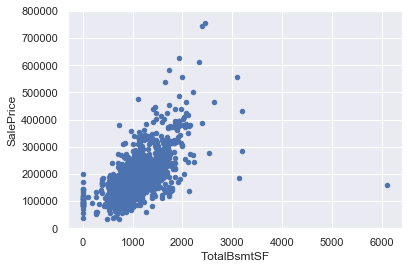

```python
#scatter plot totalbsmtsf/saleprice
var = 'TotalBsmtSF'
data = pd.concat([df_train['SalePrice'], df_train[var]], axis = 1)
data.plot.scatter(x=var, y ='SalePrice', ylim=(0,800000))
```

Strong linear (exponenetial)

**Relationship with categorical features**

```
(-0.5, 9.5, 0, 800000)
```

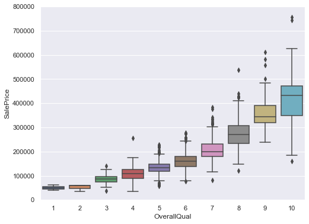

```python
#box plot overallqual/saleprice
var = 'OverallQual'
data = pd.concat([df_train['SalePrice'], df_train[var]], axis = 1)

f, ax = plt.subplots(figsize = (8, 6))
fig = sns.boxplot(x=var, y='SalePrice', data = data)
fig.axis(ymin=0, ymax = 800000)
```

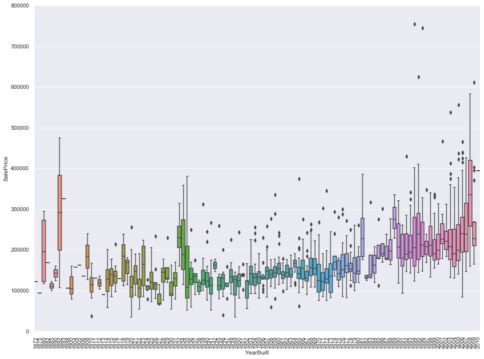

```python
var = 'YearBuilt'
data = pd.concat([df_train['SalePrice'], df_train[var]], axis = 1)
f, ax = plt.subplots(figsize = (16, 12))
fig = sns.boxplot(x=var, y='SalePrice', data = data)
fig.axis(ymin=0, ymax = 800000)
plt.xticks(rotation =90)
```

Although it's not a strong tendency, I'd say that SalePrice is more prone to spend more money in new stuff tahn in old relics

**Note**: We don't know if 'SalePrice; is in constant prices. Constant prices try to remove the effect of inflation

**In summary**

Stories aside, we can conclude that:

- 'GrLivArea' and 'TotalBsmtSF' seem to be linearly related with 'SalePrice'. Both relationships are positive, which means that as one variable increases, the other also increases. In the case of 'TotalBsmtSF', we can see that the slope of the linear relationship is particularly high.
- 'OverallQual' and 'YearBuilt' also seem to be related with 'SalePrice'. The relationship seems to be stronger in the case of 'OverallQual', wher the box plot shows how sales prices increase with the overall quality.

# Keep calm and work smart

Until now we just followed out intuition and analysized the variables we thought were important. In spite of our efforts to give an objective character to our analysis, we must say that our starting point was subjective.

**The 'plasma soup'**

To explore the universe, we will start with some practical recipes to make sense of our 'plasma soup':

- Correlation matrix (heatmap stype)
- 'SalePrice' correlation matrix (zoomed heatmap style)
- Scatter plots between the most correlated variables

## Correlation matrix(heatmap style)

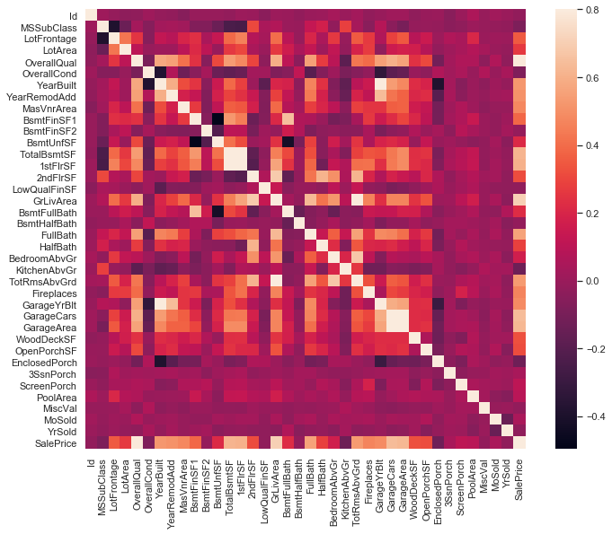

```python
#correlation matrix (heatmap style)
corrmat = df_train.corr()
f, ax = plt.subplots(figsize=(12,9))
sns.heatmap(corrmat, vmax =.8, square= True)
```

At first sight, there are two red colored squares that get my attention. The first one refers to the 'TotalBsmtSF' and '1stFlrSF' variables, and the second one refers to the 'GarageX' varables. Both cases show how significant the correlation is between these variables. Actually, this correlation is so strong that it can indicate a situation of multicollinearity. If we think about these variables, we can conclude that they almost the same information so multicollinearity really occurs. Heatmaps are great to detect his kind of situations and in problems dominated by feature selections.

Another thing that got my attention was the 'SalePrice' correlations. We can see our well-known 'GrLivArea', 'TotalBsmtSF', and 'OverallQual', but we can also see many other variables that should be taken into account. That;s what we will do next.

**SalePrice correlation matrix (zoomed heatmap style)**

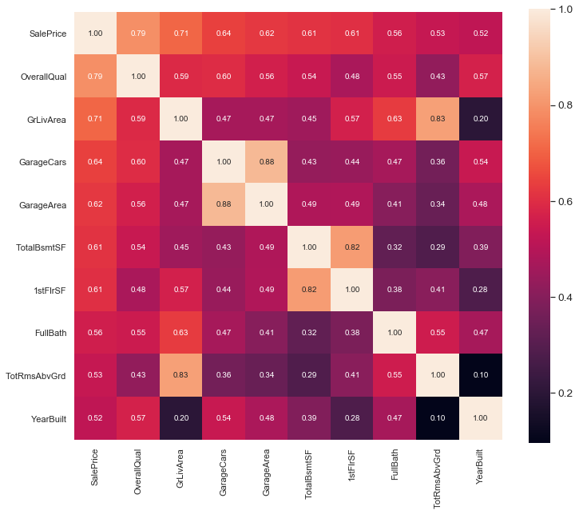

```python
#saleprice correlation matrix
k = 10 #number of variables for heatmap
corrmat = df_train.corr()
cols = corrmat.nlargest(k, 'SalePrice')['SalePrice'].index

cm = np.corrcoef(df_train[cols].values.T)

f, ax = plt.subplots(figsize = (12,10))

sns.set(font_scale=1.25)

hm = sns.heatmap(cm, cbar = True, annot = True, square = True, fmt = '.2f',
                 annot_kws= {'size' :10}, yticklabels =cols.values, xticklabels = cols.values)
plt.show()
```

According to our crystal ball, these are the variables most correlated with 'SalePrice'. My thoughts on this:

- OverallQual, GrLivArea and TotalBsmtSF are strongly correlated with SalePrice. Check!
- GarageCars and GarageArea are also some of the most strongly correlated variables. However, as we discussed in the last sub-point, the number of cars that fit into the garage is a consequence of the garage area. 'GarageCars' and 'GarageArea' are like twin brothers. You'll never be able to distinguish them. Therefore, we just need one of these variables in our analysis. Therefore, we jsut need one of these variables in our analysis (we can keep 'GarageCars' since its correlation with 'SalePrice' is higher.
- TotalBsmtSF and 1stFloor also seem to be twin brothers. We can keep 'TotalBsmtSF' just to say that our first guess was right (re-read 'So..What can we expect?')
- FullBath?
- TotRmsAbvGrd and GrLivArea twin brothers again. Is this dataset from Chernoby?
- YearBuit. It seems that YearBuilt is slightly correlated with SalePrice. Honestly, it scares to think about 'YearBuilt'.

Let's proceed to the scatter plots

**Scatter plots between 'SalePrice' and correlated variables

Get ready for what you're about to see. I must confess that the first time I saw these scatter plots. I was totally blown away! So much information in so short space.. It's just amazing.

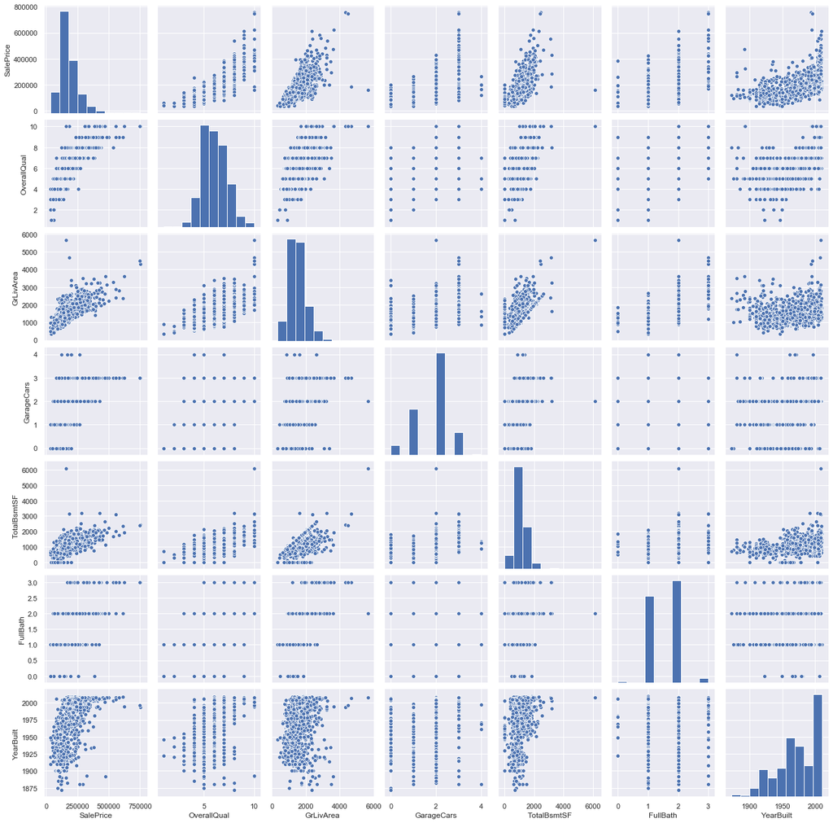

```python
#scatterplot

sns.set()
cols = ['SalePrice', 'OverallQual', 'GrLivArea', 'GarageCars', 'TotalBsmtSF', 'FullBath', 'YearBuilt']
sns.pairplot(df_train[cols], size = 2.5)
plt.show()
```

Although we already know some of the main figures, this mega scatterplot gives us a reasonable idea about variables relationships.

One of the figures we may find interesting is the one between 'TotalBsmtSF' and 'GrLiveArea'. In this figure we can see the dots drawing a linear line, which almost acts like a border. It totally makes sense that the majority of the dots stay below that line. Basement areas can be equal to the above ground living area, but it is not expected a basemetn area bigger than the above ground living area

The plot concerning 'SalePrice' and 'YearBuilt' can also make us think. In the bottom of the dots cloud, we see that almost appears to be a shy exponential function (be creative). We can also see this same tendency in the upper limit of the dot cloud. I jsut wanted to say that prices are increasing faster now

# Missing data

Important questions when thinking about missing data:

- How prevalent is the missing data?
- Is missing data random or does it have a pattern?

The answer to these questions important for practical reasons because missing data can imply a reduction of the sample size. This can prevent us from proceeding with the analysis. Moreover, from a substantive perspective, we need to ensure that the missing data process is not biased and hiding an inconvenient truth.

```python
#missing data
total = df_train.isnull().sum().sort_values(ascending = False)
percent = (df_train.isnull().sum()/df_train.isnull().count()).sort_values(ascending = False)
missing_data = pd.concat([total, percent], axis = 1, keys = ['Total', 'Percent'])
missing_data.head(20)
```

|  | Total | Percent |
| --- | --- | --- |
| PoolQC | 1453 | 0.995205 |
| MiscFeature | 1406 | 0.963014 |
| Alley | 1369 | 0.937671 |
| Fence | 1179 | 0.807534 |
| FireplaceQu | 690 | 0.472603 |
| LotFrontage | 259 | 0.177397 |
| GarageCond | 81 | 0.055479 |
| GarageType | 81 | 0.055479 |
| GarageYrBlt | 81 | 0.055479 |
| GarageFinish | 81 | 0.055479 |
| GarageQual | 81 | 0.055479 |
| BsmtExposure | 38 | 0.026027 |
| BsmtFinType2 | 38 | 0.026027 |
| BsmtFinType1 | 37 | 0.025342 |
| BsmtCond | 37 | 0.025342 |
| BsmtQual | 37 | 0.025342 |
| MasVnrArea | 8 | 0.005479 |
| MasVnrType | 8 | 0.005479 |
| Electrical | 1 | 0.000685 |
| Utilities | 0 | 0.000000 |

Let's analyse thí to understand how to handle the missing data

We'll consider that when more than 15% of the data is missing, we should delete the corresponding variable and pretend it never existed. This means that we will not try any trick to fill the missing data in these cases. According to this, there is a set of variables, that we should delete. The point is: will we miss this data? I don't think so. None of these variables seem to be very important, since most of them are not aspects in which we think about when buying a house (maybe that's the reason why data is missing). Moreover, looking closer at the variables, we could say that variables like 'PoolQC', 'MiscFeature' and 'FireplaceQu' are strong candidates for outliers, so we'll be happy to delete them.

Regarding 'MasVnrArea' and 'MasVnType', we can consider that these variables are not essential. Futhermore, they have a strong correlation with 'YearBuilt' and 'OverallQual' which are already considered. Thus, we will not lose information if we delete 'MasVnrArea' and 'MasVnrType'.

```python
#dealing with missing data

df_train = df_train.drop(missing_data[missing_data['Total']>= 1].index, axis = 1)

df_train.isnull().sum().max()
```

```
0
```

# Outliers

Outliers is also something that we should be aware of. Why? Because outliers can markedly affect our model and can be a valuable source of information. providing us insights about specific behavours.

Outliers is a complex subject and it deserves more attention. Here, we'll just do a quick analysis through the standard deviation of 'SalePrice; and set of scatter plots.

**Univariate analysis**

The primary concern here is to etablish a threshold that defines an observation as an outlier. To do so, we;ll standardize the data. In this context, data standardization means converting data values to have mean of 0 and a standard deviation of 1.

```python
#standardizing data

saleprice_scaled = StandardScaler().fit_transform(df_train['SalePrice'][:, np.newaxis])
low_range = saleprice_scaled[saleprice_scaled[:, 0].argsort()][:10]
high_range = saleprice_scaled[saleprice_scaled[:, 0].argsort()][-10:]

print('outer range (low) of the distribution:')
print(low_range)
print('/nouter range (high) of the distribution:')
print(high_range)
```

```
outer range (low) of the distribution:
[[-1.83870376]
 [-1.83352844]
 [-1.80092766]
 [-1.78329881]
 [-1.77448439]
 [-1.62337999]
 [-1.61708398]
 [-1.58560389]
 [-1.58560389]
 [-1.5731    ]]
/nouter range (high) of the distribution:
[[3.82897043]
 [4.04098249]
 [4.49634819]
 [4.71041276]
 [4.73032076]
 [5.06214602]
 [5.42383959]
 [5.59185509]
 [7.10289909]
 [7.22881942]]
```

How 'SalePrice' looks with her nre clothes:

- Low range values are similar and not too far from 0
- High range values are far from 0 and the 7 something values are really out of range

For now, we won't consider any of these values as an outlier but we should be careful with those 7. something values

**Bivariate analysis**

We already know the following scatter plots by heart. However, when we look to things from new perspective, there's always something to discover. As Alan Key said, ' a change in perspective is worth 80 IQ points'

[output not shown]

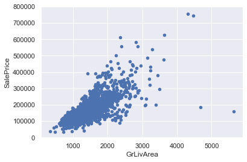

```python
# bivate analysis saleprice/grlivarea

var = 'GrLivArea'
data = pd.concat([df_train['SalePrice'], df_train[var]], axis = 1)
data.plot.scatter(x=var, y='SalePrice', ylim = (0, 800000))
```

```python
#deleting points
df_train.sort_values(by = 'GrLivArea', ascending = False)[:2]
df_train = df_train.drop(df_train[df_train['Id'] == 1299].index)
df_train = df_train.drop(df_train[df_train['Id'] == 524].index)
```

[output not shown]

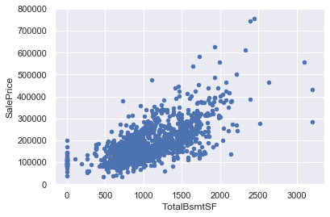

```python
#bivariate analysis saleprice/grlivarea
var = 'TotalBsmtSF'
data = pd.concat([df_train['SalePrice'], df_train[var]], axis=1)
data.plot.scatter(x=var, y='SalePrice', ylim=(0,800000));
```

We can feel tempted to eliminate some observations (e.g. TotalBsmtSF > 3000) but I suppose it's not worth it. We can live with that, so we'll not do anything.

# Getting hard core

In Ayn Rand's novel, 'Atlas Shrugged', there is an often-repeated question: who is John Galt? A big part of the book is about the quest to discover the answer to this question.

I feel Randian now. Who is 'SalePrice'?

The answer to this question lies in testing for the assumptions underlying the statistical bases for multivariate analysis. We already did some data cleaning and discovered a lot about 'SalePrice'. Now it's time to go deep and understand how 'SalePrice' complies with the statistical assumptions that enables us to apply multivariate techniques.

According to Hair et al. (2013), four assumptions should be tested:

`Normality` - When we talk about normality what we mean is that the data should look like a normal distribution. This is important because several statistic tests rely on this (e.g. t-statistics). In this exercise we'll just check univariate normality for 'SalePrice' (which is a limited approach). Remember that univariate normality doesn't ensure multivariate normality (which is what we would like to have), but it helps. Another detail to take into account is that in big samples (>200 observations) normality is not such an issue. However, if we solve normality, we avoid a lot of other problems (e.g. heteroscedacity) so that's the main reason why we are doing this analysis.

`Homoscedasticity` - I just hope I wrote it right. Homoscedasticity refers to the 'assumption that dependent variable(s) exhibit equal levels of variance across the range of predictor variable(s)' (Hair et al., 2013). Homoscedasticity is desirable because we want the error term to be the same across all values of the independent variables.

Linearity- The most common way to assess linearity is to examine scatter plots and search for linear patterns. If patterns are not linear, it would be worthwhile to explore data transformations. However, we'll not get into this because most of the scatter plots we've seen appear to have linear relationships.

Absence of correlated errors - Correlated errors, like the definition suggests, happen when one error is correlated to another. For instance, if one positive error makes a negative error systematically, it means that there's a relationship between these variables. This occurs often in time series, where some patterns are time related. We'll also not get into this. However, if you detect something, try to add a variable that can explain the effect you're getting. That's the most common solution for correlated errors.

What do you think Elvis would say about this long explanation? 'A little less conversation, a little more action please'? Probably... By the way, do you know what was Elvis's last great hit?

(...)

The bathroom floor.

In the search for normality The point here is to test 'SalePrice' in a very lean way. We'll do this paying attention to:

- Histogram - Kurtosis and skewness.
- Normal probability plot - Data distribution should closely follow the diagonal that represents the normal distribution.

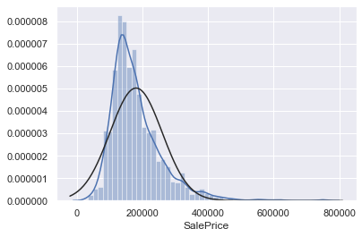

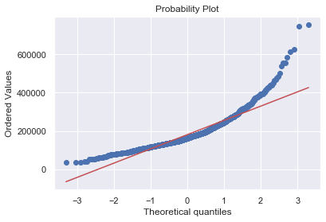

```python
#histogram and normal probability plot
sns.distplot(df_train['SalePrice'], fit=norm);
fig = plt.figure()
res = stats.probplot(df_train['SalePrice'], plot=plt)
```

Ok, 'SalePrice' is not normal. It shows 'peakedness', positive skewness and does not follow the diagonal line.

But everything's not lost. A simple data transformation can solve the problem. This is one of the awesome things you can learn in statistical books: in case of positive skewness, log transformations usually works well. When I discovered this, I felt like an Hogwarts' student discovering a new cool spell.

Avada kedavra!

```python
#applying log transformation
df_train['SalePrice'] = np.log(df_train['SalePrice'])
```

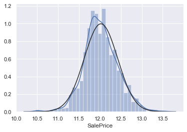

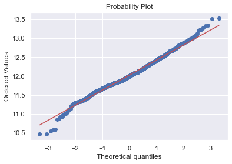

```python
#transformed histogram and normal probability plot
sns.distplot(df_train['SalePrice'], fit=norm);
fig = plt.figure()
res = stats.probplot(df_train['SalePrice'], plot=plt)
```

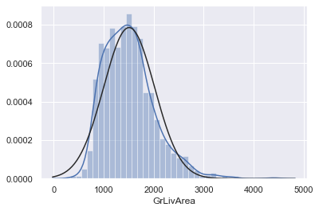

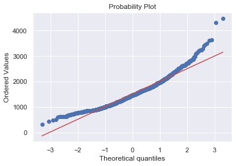

```python
#histogram and normal probability plot
sns.distplot(df_train['GrLivArea'], fit=norm);
fig = plt.figure()
res = stats.probplot(df_train['GrLivArea'], plot=plt)
```

```python
#data transformation
df_train['GrLivArea'] = np.log(df_train['GrLivArea'])
```

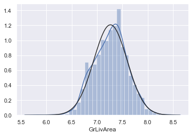

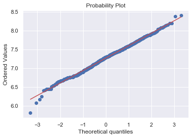

```python
#transformed histogram and normal probability plot
sns.distplot(df_train['GrLivArea'], fit=norm);
fig = plt.figure()
res = stats.probplot(df_train['GrLivArea'], plot=plt)
```

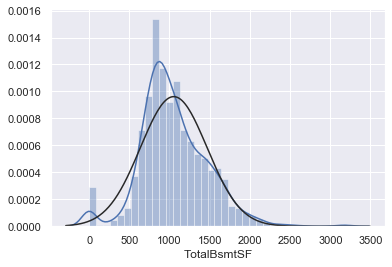

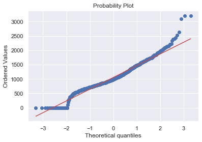

```python
#histogram and normal probability plot
sns.distplot(df_train['TotalBsmtSF'], fit=norm);
fig = plt.figure()
res = stats.probplot(df_train['TotalBsmtSF'], plot=plt)
```

Ok, now we are dealing with the big boss. What do we have here?

Something that, in general, presents skewness.

- A significant number of observations with value zero (houses without basement).
- A big problem because the value zero doesn't allow us to do log transformations.
- To apply a log transformation here, we'll create a variable that can get the effect of having or not having basement (binary variable). Then, we'll do a log transformation to all the non-zero observations, ignoring those with value zero. This way we can transform data, without losing the effect of having or not basement.

I'm not sure if this approach is correct. It just seemed right to me. That's what I call 'high risk engineering'.

```python
#create column for new variable (one is enough because it's a binary categorical feature)
#if area>0 it gets 1, for area==0 it gets 0
df_train['HasBsmt'] = pd.Series(len(df_train['TotalBsmtSF']), index=df_train.index)
df_train['HasBsmt'] = 0
df_train.loc[df_train['TotalBsmtSF']>0,'HasBsmt'] = 1
```

```python
#transform data
df_train.loc[df_train['HasBsmt']==1,'TotalBsmtSF'] = np.log(df_train['TotalBsmtSF'])
```

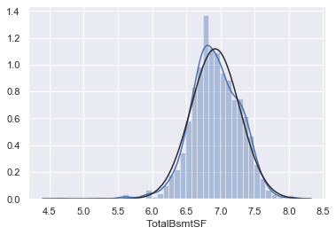

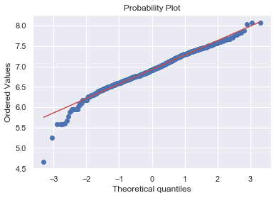

```python
#histogram and normal probability plot
sns.distplot(df_train[df_train['TotalBsmtSF']>0]['TotalBsmtSF'], fit=norm);
fig = plt.figure()
res = stats.probplot(df_train[df_train['TotalBsmtSF']>0]['TotalBsmtSF'], plot=plt)
```

**In the search for writting 'homoscedasticity' right at the first attempt**

The best approach to test homoscedasticity for two metric variables is graphically. Departures from an equal dispersion are shown by such shapes as cones (small dispersion at one side of the graph, large dispersion at the opposite side) or diamonds (a large number of points at the center of the distribution).

Starting by 'SalePrice' and 'GrLivArea'...

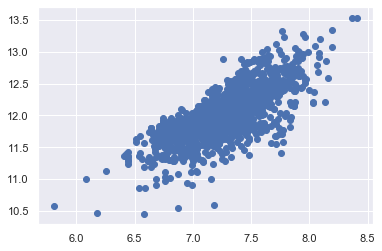

```python
#scatter plot
plt.scatter(df_train['GrLivArea'], df_train['SalePrice'])
```

Older versions of this scatter plot (previous to log transformations), had a conic shape (go back and check 'Scatter plots between 'SalePrice' and correlated variables (move like Jagger style)'). As you can see, the current scatter plot doesn't have a conic shape anymore. That's the power of normality! Just by ensuring normality in some variables, we solved the homoscedasticity problem.

Now let's check 'SalePrice' with 'TotalBsmtSF'.

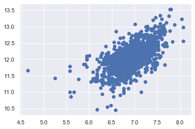

```python
#scatter plot
plt.scatter(df_train[df_train['TotalBsmtSF']>0]['TotalBsmtSF'], df_train[df_train['TotalBsmtSF']>0]['SalePrice'])
```

We can say that, in general, 'SalePrice' exhibit equal levels of variance across the range of 'TotalBsmtSF'. Cool!

**Last but not the least, dummy variables**

Easy mode

```python
#convert categorical variable into dummy
df_train = pd.get_dummies(df_train)
```

# Conclusion

That's it! We reached the end of our exercise.

Throughout this kernel we put in practice many of the strategies proposed by Hair et al. (2013). We philosophied about the variables, we analysed 'SalePrice' alone and with the most correlated variables, we dealt with missing data and outliers, we tested some of the fundamental statistical assumptions and we even transformed categorial variables into dummy variables. That's a lot of work that Python helped us make easier.

It's up to you to find out.